# Meeting_with_Mike_9_28_2017

#### loading in of data

```r
xylem <- read.table("/Users/gturco/Documents/Projects/z_stack/data/experiments/all_d.txt", header=TRUE)
xylem_count <- read.table("/Users/gturco/Documents/Projects/z_stack/data/experiments/count_d.txt", header=TRUE)
xylem_count_logged <- read.table("/Users/gturco/Documents/Projects/z_stack/data/experiments/all_d_no_zero.txt", header=TRUE)


xylem <- as.data.frame(xylem)
xylem$VND7_log = log2(xylem$VND7)

xylem_count <- as.data.frame(xylem_count)
xylem_count$VND7_log = log2(xylem_count$VND7)


xylem_count_logged <- as.data.frame(xylem_count_logged)
xylem_count_logged$VND7_log = log2(xylem_count_logged$VND7)
xylem_count_logged$percent_xylem = log2(xylem_count_logged$percent_xylem)
```

#### Here I ran the R segemented pakage to run a a pieacewise linear regression on my data. I told it to caluclate two breakpoints, the graph below shows the two it picked. Mike and I agree that it looks like there are 4 breaks here rather than 2 and that the fit could be much better.

```r
library(segmented)
```

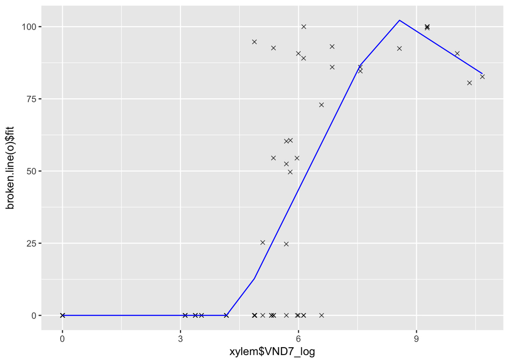

```r
library(ggplot2)

out.lm <- lm(percent_xylem ~ VND7_log, data = xylem)
o <- segmented(out.lm, seg.Z = ~VND7_log , psi = list(VND7_log = c(4,5)),
  control = seg.control(display = FALSE)
)

dat2 = data.frame(x = xylem$VND7_log, y = broken.line(o)$fit)

 p <- ggplot(data = xylem, aes(xylem$VND7_log, y = broken.line(o)$fit))+ geom_jitter(data = xylem, aes(xylem$VND7_log, y = xylem$percent_xylem),alpha = 0.7,  shape = 4)

p + geom_line(data = dat2, color = 'blue')
```

#### This gives a p-value for breakpoints in model, I might use this to test for switch in transcriptional data

```r
davies.test(out.lm, seg.Z = ~VND7_log , k=4)
```

[output not shown]

### These are the breakpoints

```r
o
```

```
## Call: segmented.lm(obj = out.lm, seg.Z = ~VND7_log, psi = list(VND7_log = c(4,
##     5)), control = seg.control(display = FALSE))
##
## Meaningful coefficients of the linear terms:
## (Intercept)     VND7_log  U1.VND7_log  U2.VND7_log
##  -2.450e-14    1.441e-14    2.745e+01   -3.623e+01
##
## Estimated Break-Point(s):
## psi1.VND7_log  psi2.VND7_log
##         4.413          8.241
```

#### Mike helped me write code on how to find breakpoints that better fit a step model these are the breakpoints from my code, I think they look a lot better :) Here we force two points of refrence and then find the points inbetween that best fit a linear model and the two fixed points. Three segments a:ab,b:bc,and c:cd. Find A and C breakpoints with lowest SE and B to C slope with lowest r-sqaured value. A and C are forced to stay constant, min and max.

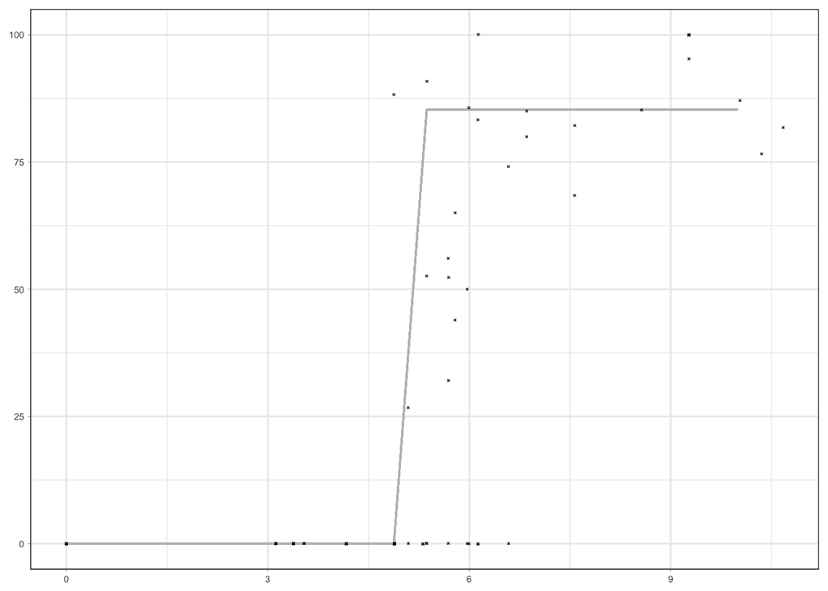

```r
ggplot(data = xylem_count, aes(VND7_log, y=percent_xylem )) + geom_segment(y= 0, x= 0, xend = 4.8772339999999996, yend = 0, color="grey") +geom_segment(y= 85.29761, x= 5.3666520000000002, xend = 10, yend = 85.29761, color="grey") +  geom_segment(x= 4.8772339999999996, y= 0, xend = 5.3666520000000002, yend = 85.29761, color="grey") + geom_jitter(alpha = 0.7, size=0.2, shape = 4) + theme_bw() + theme(legend.position ="none", text=element_text(size=7), panel.margin = unit(0, "cm"), axis.ticks = element_line(size = 0.1), axis.line = element_line(size = 0.1), axis.ticks.length = unit(0.05, "cm"), axis.ticks.margin =unit(0, "cm")) + xlab(NULL) + ylab(NULL)
```

```r
x <- sort(xylem$VND7_log)[21:34]
y <- xylem$percent_xylem[order(xylem$VND7_log)][21:34]

summary(lm(y~x))
```

```
##
## Call:
## lm(formula = y ~ x)
##
## Residuals:
##     Min      1Q  Median      3Q     Max
## -24.721 -22.288 -14.067   1.504  80.894
##
## Coefficients:
##             Estimate Std. Error t value Pr(>|t|)
## (Intercept)   -94.59     229.50  -0.412    0.687
## x              22.23      44.85   0.496    0.629
##
## Residual standard error: 36.22 on 12 degrees of freedom
## Multiple R-squared:  0.02007,    Adjusted R-squared:  -0.06159
## F-statistic: 0.2457 on 1 and 12 DF,  p-value: 0.629
```

```r
## Slope
 lm(y ~ x)$coeff[2]
```

```
##        x
## 22.23189
```

#### Stochastic noise and variance for a switch with log-log values expect to see low noise at the min and max vlaues and more noise at switch. We expect the SE at these points to be double if switch and half the amount if the relationship is more linear.

#### This is what I have so far for binning data but need to repeat with log-log values

```r
## to make the same order we see when ploting
x_axis <- xylem$VND7_log
y_axis <- xylem$percent_xylem
window_size <- 0.5
windows <- seq(min(x_axis),max(x_axis), by = window_size)

get_stats <- function(w, x_axis,y_axis, window_size) {
  cord <- which(x_axis >= w & x_axis <= w+ window_size)
  print(cord)
  se = sd(y_axis[cord])/length(y_axis[cord])
  return(se)
  #return(c(se,mean(y_axis[cord])))

}


y <- lapply(windows,get_stats, x_axis=x_axis, y_axis=y_axis,window_size=window_size )
```

```
## [1]  5  6  7 54 55 56
## integer(0)
## integer(0)
## integer(0)
## integer(0)
## integer(0)
## [1] 12 13 14 15 16 17 18 19
## [1] 1 2
## [1] 50 51 52 53
## [1] 20 21 22 23 61 62
## [1] 30 31 32 33 34 35 36 37
##  [1] 24 25 26 27 28 29 38 39 40 41
## [1] 46 47 48 49
## [1]  3  4 44 45
## integer(0)
## [1] 42 43
## integer(0)
## [1] 9
## [1] 57 58 59 60
## integer(0)
## [1] 10 11
## [1] 8
```

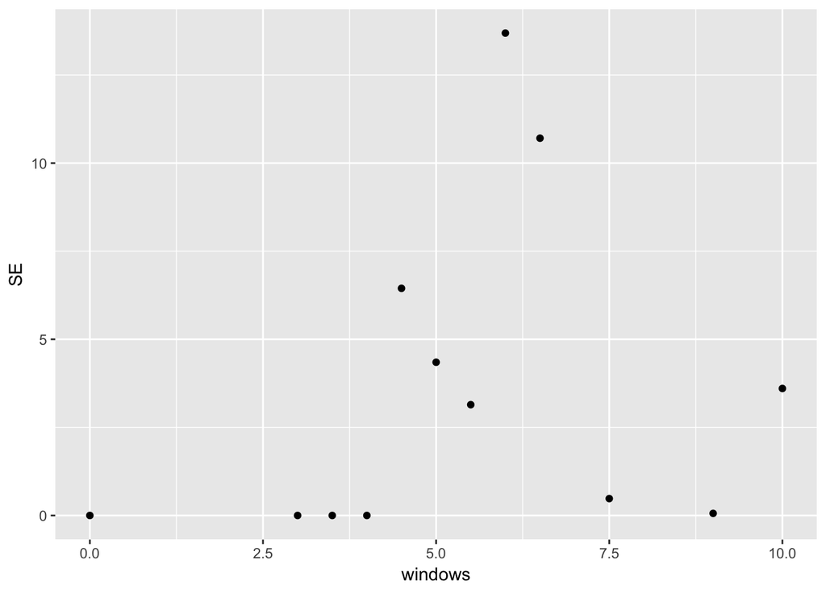

```r
SE <- unlist(y)
z <- data.frame(SE,windows)
z <- na.omit(z)

ggplot(z,aes(windows,SE)) + geom_point()
```